Profesor: [Julio Antonio Soto](https://twitter.com/julio_a_soto)

# Python numérico: Numpy

Numpy (Numerical Python) es, probablemente, la biblioteca más importante de todo el lenguaje Python (más allá de las incluídas en la biblioteca estándar). Al mismo tiempo, es la bilbioteca de álgebra lineal más conocida y potente que hay a día de hoy.

## Índice

1. Las listas de Python
2. ¡Numpy al rescate!
3. Tiempo muerto: tiempo de ejecución del código
   1. Numpy es rápido
4. Conceptos básicos
   1. Creando arrays
   2. Tipos de dato
5. Operaciones con Numpy
6. Indexado y slices de arrays
   1. Indexado booleano
7. Métodos estadísticos con Numpy
8. Álgebra lineal con Numpy
   1. Multiplicación de matrices
   2. Inversa de una matriz
   3. Concatenado de arrays y matrices
9. Generación de números aleatorios
10. Dibuja con Numpy: Matplotlib
    1. Control de los gráficos

## 1. Las listas de Python

A estas alturas, probablemente ya conozcas de sobra las listas de Python. Son flexibles, fáciles de utilizar y muy versátiles. En una lista, podemos incluir diferentes tipos de objeto:

```python
mi_lista = [1, 3.14, "hola", 0x3b] # 0x3b es el número hexadecimal 3b, que Python
                                   # traduce automáticamente a su equivalente
                                   # decimal, que resulta ser el número 59
```

Gracias a su naturaleza mutable, podemos añadir y eliminar elementos de una lista ya creada:

```python
mi_lista.append("otro elemento")
```

```python
print(mi_lista)
```

```
[1, 3.14, 'hola', 59, 'otro elemento']
```

```python
# Podemos eliminar el último elemento de una
# lista con del, y haciendo referencia al
# último elemento utilizando len(). Como los
# índices en Python empiezan por 0, el último
# elemento es la longitud de la lista menos 1:
del mi_lista[len(mi_lista)-1]
```

```python
print(mi_lista)
```

```
[1, 3.14, 'hola', 59]
```

```python
# Otra forma más sencilla de eliminar el último
# elemento de una lista, es utilizar el método
# .pop():
mi_lista.pop()
print(mi_lista)
```

```
[1, 3.14, 'hola']
```

Gracias también a que son iterables, podemos hacer muchas cosas con las listas de Python. Incluso las podemos tratar como vectores. Una operación matemática muy común podría ser multiplicar un escalar (por ejemplo el número $2$) por un vector (por ejemplo $[1,2,3,4]$). En la práctica, el resultado de esta operación no es más que multiplicar cada elemento del vector por nuestro escalar. Podríamos hacerlo así con listas de Python:

```python
escalar = 2
vector = [1,2,3,4]
resultado = []

for elemento in vector:
    resultado.append(escalar * elemento)

print(resultado)
```

```
[2, 4, 6, 8]
```

Sencillo, ¿no? De momento sí. No obstante, ¿y si queremos operar con matrices?

Podemos representar matrices en Python, por ejemplo $\begin{bmatrix}1 & 2 & 3 & 4\\5 & 6 & 7 & 8\\9 & 10 & 11 & 12\end{bmatrix}$ generando listas con listas dentro:

```python
matriz = [[1,2,3,4],[5,6,7,8],[9,10,11,12]]
print(matriz)
```

```
[[1, 2, 3, 4], [5, 6, 7, 8], [9, 10, 11, 12]]
```

Vamos a intentar hacer lo mismo: multiplicar un escalar, pero esta vez por nuestra matriz: $2 \cdot \begin{bmatrix}1 & 2 & 3 & 4\\5 & 6 & 7 & 8\\9 & 10 & 11 & 12\end{bmatrix}$. Efectivamente, el resultado es el de multiplicar cada número de nuestra matriz por el escalar:

```python
# Aquí la cosa ya se complica. Tenemos que utilizar dos iteraciones
# (bucles for) y utilizar dos listas distintas para ir
# guardando los resultados:

escalar = 2
resultado_final = []
resultado_de_cada_fila = []

for fila in matriz:
    for elemento in fila:
        resultado_de_cada_fila.append(escalar * elemento)
    # Una vez generados los resultados de cada fila
    # de la matriz, la añadimos a nuestra matriz resultado
    # final:
    resultado_final.append(resultado_de_cada_fila)
    # Y "limpiamos" la lista resultado_de_cada_fila,
    # volviendo a definirla como una lista vacía:
    resultado_de_cada_fila = []

print(resultado_final)
```

```
[[2, 4, 6, 8], [10, 12, 14, 16], [18, 20, 22, 24]]
```

La cosa se va complicando, ¿verdad? Pues imagínate cómo sería el código para multiplicar una matriz por un vector, o dos matrices... A la larga, acabas escribiendo muchísimo código para conceptos matemáticamente bastante sencillos.

## 2. ¡Numpy al rescate!

Numpy fue diseñado para hacer este tipo de cálculos mucho más sencillos y rápidos. No deja de ser una biblioteca Python, así que podemos importarla fácilmente:

```python
import numpy
```

Numpy nos ofrece una serie de objetos nuevos. El más importante es el array (que también verás por Internet como ndarray). Un array es similar a las listas de Python. De hecho, se puede construir un array con `numpy.array(y_una_lista_de_python)`:

```python
array = numpy.array([1,2,3,4])
```

¿Recuerdas el bucle `for` que tuvimos que hacer para multiplicar el escalar por el vector? Utilizando arrays de Numpy, ya no es necesario:

```python
# Numpy es muy listo, e infiere que si multiplicas
# un escalar por un array, es que quieres hacer
# una multiplicación de escalar x vector:
escalar = 2
resultado = escalar * array

print(resultado)
```

```
[2 4 6 8]
```

Más sencillo que con el bucle `for`, ¿verdad? ¿Y para multiplicar el escalar por la matriz?

```python
escalar = 2
matriz = numpy.array([[1,2,3,4],[5,6,7,8],[9,10,11,12]])

resultado = escalar * matriz
print(resultado)
```

```
[[ 2  4  6  8]
 [10 12 14 16]
 [18 20 22 24]]
```

No solo es mucho más agradable de escribir, sino que encima, los Notebooks son muy listos y "reconocen" los objetos de Numpy, ve que es una matriz, y lo imprime con su forma matricial (lo cual facilita la lectura de los resultados). Y encima, resulta que la ejecución del código es mucho más rápida...

## 3. Tiempo muerto: tiempo de ejecución del código

Muchas veces nos interesa saber lo rápido que es el código que escribimos. Python nos ofrece muchas formas de medir cuánto tarda en ejecutarse un trozo de nuestro código; la forma más sencilla si estamos trabajando desde un notebook, es con el "comando mágico" `%timeit`.

Los comandos mágicos son sentencias especiales que podemos escribir en las celdas de IPython/Jupyter, para realizar acciones "externas" a lo que es nuestro código normal y corriente Python. Suelen ir precedidas por `%` o `%%`. Hagamos la prueba: que `%timeit` nos diga cuánto tarda Python en sumar $3+4$:

```python
%timeit 3+4
```

```
The slowest run took 67.52 times longer than the fastest. This could mean that an intermediate result is being cached.
10000000 loops, best of 3: 16.5 ns per loop
```

Vemos que corre el código muchas veces, con el fin de conseguir resultados más fiables. $3+4$ tarda muy poquito en sumarse, como podemos ver (cuestión de nanosegundos).

### 3.A. Numpy es rápido

Vamos a ver cuánto tarda la ejecución de nuestro producto de escalar por matriz hecha "a mano" con listas de Python:

```python
# Vamos a meter el código dentro de una función,
# para poder pasarlo por %timeit más fácilmente.
# Pero el código es exactamente el mismo:
def escalar_por_matriz(escalar, matriz):
    resultado_final = []
    resultado_de_cada_fila = []
    for fila in matriz:
        for elemento in fila:
            resultado_de_cada_fila.append(escalar * elemento)
        resultado_final.append(resultado_de_cada_fila)
        resultado_de_cada_fila = []
    return resultado_final
```

```python
%timeit escalar_por_matriz(2, [[1,2,3,4],[5,6,7,8],[9,10,11,12]])
```

```
100000 loops, best of 3: 2.95 µs per loop
```

Y ahora vamos a hacer la prueba con Numpy:

```python
# En el caso de Numpy, el código es mucho
# más cortito. No merece la pena hacer
# una función...
escalar = 2
matriz = numpy.array([[1,2,3,4],[5,6,7,8],[9,10,11,12]])
```

```python
%timeit escalar * matriz
```

```
The slowest run took 14.05 times longer than the fastest. This could mean that an intermediate result is being cached.
1000000 loops, best of 3: 1.47 µs per loop
```

Podemos ver que el código de Numpy es algo más rápido que el escrito a mano con listas de Python. Además, nos sale un aviso de que resultados intermedios están siendo cacheados (lo cual indica que están teniendo lugar optimizaciones a nivel de la CPU).

Y eso para una operación relativamente sencilla, y con una matriz de tamaño muy pequeña. Si nuestra matriz en vez de ser de dimensiones $3 \times 4$ (tres filas x cuatro columnas), fuera de dimensiones $100 \times 100$ por ejemplo... La diferencia de rendimiento es ya de órdenes de magnitud. Comprobémoslo...

```python
# Generamos una matriz 100x100 de Python con listas "a mano":
matriz_100x100 = []
fila_de_la_matriz = []

for fila in range(100):
    for elemento in range(100):
        fila_de_la_matriz.append(elemento)
    matriz_100x100.append(fila_de_la_matriz)
    fila_de_la_matriz = []
```

```python
# Imprimimos las primeras dos filas de la matriz
# (de las 100 que tiene), para ver que efectivamente
# cada fila tiene 100 elementos (del número 0 al 99)
print(matriz_100x100[:2])

# E imprimimos la longitud de la lista, que como
# es una lista de Python normal, nos va a dar el
# número de filas:
print(len(matriz_100x100))
```

```
[[0, 1, 2, 3, 4, 5, 6, 7, 8, 9, 10, 11, 12, 13, 14, 15, 16, 17, 18, 19, 20, 21, 22, 23, 24, 25, 26, 27, 28, 29, 30, 31, 32, 33, 34, 35, 36, 37, 38, 39, 40, 41, 42, 43, 44, 45, 46, 47, 48, 49, 50, 51, 52, 53, 54, 55, 56, 57, 58, 59, 60, 61, 62, 63, 64, 65, 66, 67, 68, 69, 70, 71, 72, 73, 74, 75, 76, …
100
```

Así que tenemos nuestra matriz $100 \times 100$ hecha con listas de Python. Como ya hicimos la función `escalar_por_matriz` antes para multiplicar un escalar por una matriz manualmente, podemos re-utilizarla. Vamos a medir los tiempos (de nuevo, multiplicando nuestra matriz por el escalar $2$):

```python
%timeit escalar_por_matriz(2, matriz_100x100)
```

```
1000 loops, best of 3: 1.1 ms per loop
```

Y ahora multiplicando con Numpy. Convertimos la lista de listas a array de Numpy primero:

```python
matriz_100x100_numpy = numpy.array(matriz_100x100)
```

Y medimos:

```python
%timeit 2 * matriz_100x100_numpy
```

```
The slowest run took 6.16 times longer than the fastest. This could mean that an intermediate result is being cached.
100000 loops, best of 3: 14.4 µs per loop
```

Esta vez, hemos conseguido una mejora muy considerable en velocidad. Creo que la diferencia de rendimiento ya es evidente...

Bueno, ya está bien de demostraciones. Resolvamos la pregunta:

**P: ¿Por qué Numpy es tan rápido?**

R: Numpy es una bilbioteca escrita en una mezcla de Python, C, Fortran y Cython, principalmente. La gracia de esto es que nos trae lo mejor de ambos mundos:

- Por un lado, su interfaz de alto nivel escrita en Python nos permite utilizar Numpy fácilmente desde Python (tal y como estamos viendo).
- Por otro lado, el núcleo de Numpy está escrito en C, Fortran y Cython, lo cual nos ofrece enormes ganacias de velocidad y eficiencia en memoria RAM para nuestras operaciones matemáticas complejas.

Y no solo eso: Numpy es una biblioteca que, a su vez, utiliza otras bibliotecas a muy bajo nivel (literalmente escritas en ceros y unos en algunos casos) que permiten exprimir todo el rendimiento de nuestro procesador. Ejemplos de estas bilbiotecas son LAPACK, BLAS e Intel MKL. Estas bibliotecas permiten optimizar las operaciones a nivel de procesador, evitando bucles `for` internos, y organizando nuestros vectores y matrices de forma contigua en los transistores de la CPU, incluso paralelizando automáticamente el código para aprovechar todos los núcleos de nuestro ordenador sin que nosotros tengamos que hacer nada.

Así que a niveles efectivos, Numpy no es solo mucho más rápido que las listas de Python, sino que llega a ser más rápido que una implementación de operaciones matriciales escrita a mano en C o C++ (a menos que seas un/una experto/a en C y computación científica a bajo nivel).

**P: ¿Y comparado con otros lenguajes/bibliotecas/suites matemáticas?**

R: Depende de con qué comparemos. No obstante, incluso comparando contra soluciones comerciales, el rendimiento de Numpy es excepcional. Vamos uno por uno:

- R: El núcleo de R está también programado en lenguajes de bajo nivel como C, C++ y Fortran. De hecho, algunas partes del lenguaje también aprovechan Atlas y BLAS. El rendimiento de R es difícil de medir, puesto que hay una gran cantidad de pequeñas bibliotecas; a diferencia de Python, donde las bibliotecas para computación científica y matemática son menos en número, pero más extensas. Para operaciones sencillas de álgebra lineal, Python con Numpy es en mis pruebas entre 3 y 10 veces más rápido; principalmente porque la gestión de memoria de R no es la más eficiente del mundo (los tipos de datos de R tienen un poco de *overhead*, lamentablemente). La *guerra* entre R y Python por el trono de mejor lenguaje para análisis de datos se libra día a día; en Internet podrás ver cientos de foros y discusiones de estilo: *"R vs Python"*, o: *"Por qué `mi-lenguaje-favorito-de-los-dos` es mucho mejor que `el-otro`"*. [Aquí](https://www.kaggle.com/forums/f/208/getting-started/t/5243/pros-and-cons-of-r-vs-python-sci-kit-learn) hay un ejemplo (bastante abierto al diálogo comparado con otros).
- MATLAB: MATLAB, al igual que R y Python, es un lenguaje interpretado que aprovecha bilbiotecas de C. No obstante, la base de código de MATLAB tiene ya más de 30 años, y se nota. Existen partes del compilador escritas en ensamblador, en C, Java e incluso Python. En la práctica, MATLAB es del orden de 20 y 50 veces más lento que Numpy con multiplicación de matrices. MATLAB destaca por su sencillez y bibliotecas externas visuales y de automatización, lo cual lo hace un lenguaje ideal para prototipar y experimentar.
- SAS Base: Misma historia que con MATLAB, solo que para encontrar el origen de la base de código para el compilador SAS no tenemos que remontarnos treinta años atrás, sino casi cuarenta. Si bien resulta complicado hacer pruebas con código equivalente (debido a la completamente distinta sintaxis de Base), mi experiencia en clientes que tenían SAS me dice que es probablemente el entorno de ejecución más lento de esta lista. SAS destaca sobre todo por su sencillez de uso, entorno integrado y soporte técnico; pero no es una herramienta de computación al nivel del resto de las mencionadas aquí.
- Spark: en realidad, Spark juega en una liga distinta en lo que a análisis de datos se refiere. Spark está pensando para cantidades de datos que el resto de programas listados no pueden digerir. Regla común: si tus datos son analizables con R/Python(Numpy) sin obtener preciosos `MemoryError` o similares, olvídate de Spark, porque será más lento que los dos lenguajes. Si obtienes los `MemoryError`, Spark es la solución (recomendación así a muy grandes rasgos).

Para entender mejor el rendimiento de Numpy y de la computación matricial en sí, recomiendo leer *[High Performance Python](http://shop.oreilly.com/product/0636920028963.do)*, de Micha Gorelick e Ian Ozsvald (O'Reilly Media), Capítulo 6.

## 4. Conceptos básicos

Ya hemos visto que podemos empezar a utilizar Numpy importando la biblioteca con

```
import numpy
```

No obstante, al hacer esto, cada vez que queramos utilizar un objeto de Numpy (como puede ser `array`), tenemos que escribir `numpy.array`. En la comunidad Python odiamos escribir más de lo necesario. Por eso, es frecuente poner "alias" a las bibliotecas en tiempo de importación. Si en lugar de `import numpy`, escribimos:

```python
import numpy as np
```

A partir de ahora podemos utilizar los objetos de Numpy con el alias `np`, que nos permite ahorrarnos unas cuantas letras en cada objeto que creemos:

```python
un_array = np.array([1,2,3,4,5,6,7])
```

Es una convención muy extendida entre los usuarios de Numpy.

### 4.A. Creando arrays

Ya hemos visto que podemos utilizar `np.array` para crear vectores y matrices de cualquier dimensión. Dentro de un `array`, todos los elementos tienen el mismo tipo de dato. Los tipos de dato de Numpy son especiales (algo distintos a los de Python normal), y se llaman `dtype`s.

Por ejemplo: si mezclamos números enteros y decimales en un mismo array, veremos que Numpy convierte los enteros a decimales, para que todo el array se quede con un tipo de dato uniforme:

```python
enteros_y_decimales = np.array([1, 2.3, 5, 6.7])
print(enteros_y_decimales)
```

```
[ 1.   2.3  5.   6.7]
```

Numpy entiende los enteros en este caso como decimales, donde la parte decimal es 0 (y no la imprime).

Podemos ver qué tipo de dato tienen los elementos de un objeto de Numpy utilizando el atributo `.dtype`:

```python
enteros_y_decimales.dtype
```

```
dtype('float64')
```

Ya vimos anteriormente que podemos generar matrices haciendo arrays de arrays, con la siguiente notación:

```python
mi_matriz = np.array([[1,2], [3,4], [5,6]])
print(mi_matriz)
```

```
[[1 2]
 [3 4]
 [5 6]]
```

Podemos sacar las dimensiones de la matriz con `.shape`:

```python
mi_matriz.shape
```

```
(3, 2)
```

Pero existen otras formas de crear arrays, además de introduciéndolas a mano. Por ejemplo: podemos crear una matriz de todo ceros con `np.zeros((filas, columnas))`. Para crear una matriz $3 \times 4$ de ceros, hacemos:

```python
np.zeros((3,4))
```

```
array([[ 0.,  0.,  0.,  0.],
       [ 0.,  0.,  0.,  0.],
       [ 0.,  0.,  0.,  0.]])
```

También podemos ver que en los Notebooks podemos ver lo que devuelve una celda sin la necesidad de escribir `print`. Así, Jupyter nos da más información: en este caso, nos muestra que es un array de Numpy.

También podemos utilizar `np.ones` para crear matrices de unos, de forma exactamente igual a la de ceros (pero con unos).

Crear matrices identidad (es decir, con unos en la diagonal principal y el resto ceros) es también muy sencillo con `np.identity(tamaño)`. Las matrices identidad siempre son cuadraras (es decir, que tienen que tener el mismo número de filas que de columnas), de forma que para crear una matriz identidad $5 \times 5$, hacemos:

```python
np.identity(5)
```

```
array([[ 1.,  0.,  0.,  0.,  0.],
       [ 0.,  1.,  0.,  0.,  0.],
       [ 0.,  0.,  1.,  0.,  0.],
       [ 0.,  0.,  0.,  1.,  0.],
       [ 0.,  0.,  0.,  0.,  1.]])
```

También podemos generar datos no uniformes. Por ejemplo: `np.arange` nos permite generar arrays desde un número inferior hasta uno superior (similar a la función `range` de la biblioteca estándar):

```python
np.arange(3,14)
```

```
array([ 3,  4,  5,  6,  7,  8,  9, 10, 11, 12, 13])
```

Del mismo modo, podemos pasarle un tercer argumento para definir que vaya saltando. Por ejemplo, cada dos números (funciona muy similar a la función builtin `range` de la biblioteca estándar):

```python
np.arange(3,14,2)
```

```
array([ 3,  5,  7,  9, 11, 13])
```

En muchos escenarios podemos partir de un array unidimensional (vector), y nos puede interesar transformarlo a una matriz. Para hacerlo, utilizamos el método `.reshape((filas, columnas))`. Supongamos el siguiente vector:

```python
mi_vector = np.arange(0,15)
mi_vector
```

```
array([ 0,  1,  2,  3,  4,  5,  6,  7,  8,  9, 10, 11, 12, 13, 14])
```

Al tener quince elementos, lo puedo transformar en una matriz, siempre y cuando las dimensiones de la matriz no denen ningún "hueco" libre. Si tenemos quince elementos, podemos crear una matriz $3 \times 5$, por ejemplo:

```python
mi_vector.reshape((3,5))
```

```
array([[ 0,  1,  2,  3,  4],
       [ 5,  6,  7,  8,  9],
       [10, 11, 12, 13, 14]])
```

También una $5 \times 3$:

```python
mi_vector.reshape((5,3))
```

```
array([[ 0,  1,  2],
       [ 3,  4,  5],
       [ 6,  7,  8],
       [ 9, 10, 11],
       [12, 13, 14]])
```

Pero no una $3 \times 4$ (porque 3 x 4 son 12, y nos quedarían tres huecos vacíos en la matriz):

```python
mi_vector.reshape((3,4))
```

```
---------------------------------------------------------------------------
ValueError                                Traceback (most recent call last)
<ipython-input-37-a10cbe6c16aa> in <module>()
----> 1 mi_vector.reshape((3,4))

ValueError: total size of new array must be unchanged
```

### 4.B. Tipos de dato

Numpy, al igual que Python, tiene varios tipos de dato numéricos. No obstante, no son realmente los mismos tipos de dato en sí, sino versiones optimizadas y mejoradas más cercanas a los tipos de C que a los de Python. Cuando nosotros tenemos una lista de Python:

```python
mi_lista = [1,2,3,4,5,6]
```

Podemos ver que en este caso el tipo de elementos de la lista son `int` normales de Python:

```python
type(mi_lista[0])
```

```
int
```

No obstante, si creamos un `np.array` a partir de dicha lista:

```python
mi_array = np.array(mi_lista)
```

Y miramos el tipo de dato:

```python
mi_array.dtype
```

```
dtype('int64')
```

Vemos que ahora es un `dtype` de Numpy que se llama `int64` (número entero de 64 bits).

Numpy tiene unos tipos numéricos mucho más ricos que el Python estándar. De todos modos, en la práctica, lo más utilizado es `int64`, `float64`, `bool`, `object` y `string_`. Probemos estos tres últimos. El de booleanos es bastante evidente:

```python
verdaderos_y_falsos = np.array([True, False, False, True])
verdaderos_y_falsos.dtype
```

```
dtype('bool')
```

El de `object` aparece cuando Numpy:

- No puede inferir qué tipo de dato tienen los elementos del array, (quizás por no ser numérico como tal, por ejemplo) por lo que los encapsula en "object" de forma genérica.
- El tipo de dato no puede ser "alisado". Por ejemplo: si creamos un array con números enteros y decimales, Numpy puede fácilmente transformar los enteros a decimales y que el resultado sea un array uniforme de decimales. En otros casos, no puede hacer este tipo de operación (por ejemplo, en arrays con strings, números y otro tipo de dato complejo mezclados).

```python
objetos = np.array([(1,2,3), (3,4), (5,6)])
objetos
```

```
array([(1, 2, 3), (3, 4), (5, 6)], dtype=object)
```

Si es un array de strings, Numpy reconoce el tipo como `S` (de string) o `U` (de Unicode) + la longitud de la string más larga del array. Esto ocurre porque Numpy guarda en memoria los elementos en bloques del mismo tamaño; por lo que el tamaño de cada bloque ha de ser lo suficientemente grande para que quepa cada elemento. Por ejemplo:

```python
strings = np.array(["uno", "dos", "tres", "cuatro"])
strings.dtype
```

```
dtype('<U6')
```

El `dtype` es `S6` (o `<U6` con Unicode, dependiendo de la versión de Numpy y Python que tengamos), porque el string más larga tiene seis letras. Por el contrario:

```python
np.array(["uno", "dos", "tres", "cuatro", "diecisiete"]).dtype
```

```
dtype('<U10')
```

Entre tipos de dato convertibles, podemos realizar la conversión con el método `.astype(dtype_destino)` sobre un array. Para indicar el dtype, lo podemos hacer con `np.nombre_del_tipo`:

```python
array_de_enteros = np.array([1,2,3,4,5,6,7])
print("dtype de array_de_enteros: " + str(array_de_enteros.dtype))

array_de_floats = array_de_enteros.astype(np.float64)
print("dtype de array_de_floats: "+ str(array_de_floats.dtype))
```

```
dtype de array_de_enteros: int64
dtype de array_de_floats: float64
```

[Aquí](https://docs.scipy.org/doc/numpy-1.10.0/reference/arrays.scalars.html#arrays-scalars-built-in) puedes encontrar un listado completo de los `dtypes` de Numpy.

## 5. Operaciones con Numpy

Ya hemos visto un ejemplo de operación de vector/matriz por escalar al principio:

```python
matriz = np.arange(0.0, 20.0).reshape((4,5))
matriz
```

```
array([[  0.,   1.,   2.,   3.,   4.],
       [  5.,   6.,   7.,   8.,   9.],
       [ 10.,  11.,  12.,  13.,  14.],
       [ 15.,  16.,  17.,  18.,  19.]])
```

```python
matriz * 2
```

```
array([[  0.,   2.,   4.,   6.,   8.],
       [ 10.,  12.,  14.,  16.,  18.],
       [ 20.,  22.,  24.,  26.,  28.],
       [ 30.,  32.,  34.,  36.,  38.]])
```

Podemos hacer este tipo de operaciones elemento a elemento con cualquier operando estándar de Python. Por ejemplo, para hacer el cuadrado de cada elemento de la matriz:

```python
matriz * matriz
```

```
array([[   0.,    1.,    4.,    9.,   16.],
       [  25.,   36.,   49.,   64.,   81.],
       [ 100.,  121.,  144.,  169.,  196.],
       [ 225.,  256.,  289.,  324.,  361.]])
```

**Cuidado:** la operación anterior no es el cuadrado de la matriz, es decir: no es multiplicación real de matrices, sino la multiplicación de cada elemento de la matriz por sí mismo. Más adelante hacermos multiplicación de matrices.

O la resta:

```python
matriz - matriz
```

```
array([[ 0.,  0.,  0.,  0.,  0.],
       [ 0.,  0.,  0.,  0.,  0.],
       [ 0.,  0.,  0.,  0.,  0.],
       [ 0.,  0.,  0.,  0.,  0.]])
```

Podemos transponer fácilmente una matriz con el método `.T`:

```python
mi_matriz = np.arange(5,15).reshape((5,2))
mi_matriz
```

```
array([[ 5,  6],
       [ 7,  8],
       [ 9, 10],
       [11, 12],
       [13, 14]])
```

```python
mi_matriz.T
```

```
array([[ 5,  7,  9, 11, 13],
       [ 6,  8, 10, 12, 14]])
```

En Numpy existen una serie de funciones llamadas *funciones universales* o `ufuncs`. Estas funciones pueden actuar sobre uno o más arrays (dependiendo de cuál), que nos permiten hacer operaciones frecuentes sobre cada uno de los elementos del array. Se invocan con `np.la_funcion(array_o_arrays_sobre_la_que_actúa)`:

```python
# La raíz cuadrada de cada elemento de la matriz la
# obtenemos con np.sqrt(array):
np.sqrt(mi_matriz)
```

```
array([[ 2.23606798,  2.44948974],
       [ 2.64575131,  2.82842712],
       [ 3.        ,  3.16227766],
       [ 3.31662479,  3.46410162],
       [ 3.60555128,  3.74165739]])
```

```python
# Otras ufuncs necesitan de varios arrays.
# generamos otra de las mismas dimensiones
# que mi_matriz (5 x 2):
mi_otra_matriz = np.array([[1,18], # Aprovecho para mostrar que
                           [12,6], # podemos escribir así las
                           [9,11], # matrices; nos puede ayudar
                           [13,15],# a ver mejor lo que ponemos.
                           [0,1]]
                         )
print(mi_matriz)
print("")
print(mi_otra_matriz)
```

```
[[ 5  6]
 [ 7  8]
 [ 9 10]
 [11 12]
 [13 14]]

[[ 1 18]
 [12  6]
 [ 9 11]
 [13 15]
 [ 0  1]]
```

```python
# Y ahora usamos la ufunc np.maximum,
# para obtener el máximo de cada elemento
# de las matrices, comparando los números
# en las mismas posiciones:

np.maximum(mi_matriz, mi_otra_matriz)
```

```
array([[ 5, 18],
       [12,  8],
       [ 9, 11],
       [13, 15],
       [13, 14]])
```

Existen bastantes `ufunc`s más. La lista completa la puedes encontrar [aquí](https://docs.scipy.org/doc/numpy-1.10.0/reference/ufuncs.html#available-ufuncs).

## 6. Indexado y slices de arrays

Ya sabemos cómo acceder al elemento número n de una lista de Python. Si tenemos una lista, y queremos obtener el tercero:

```python
mi_lista = ["perro", "gato", "loro", "lince", "python", "oso", "equidna"]

# Tanto las lista de Python como los
# arrays de Numpy empiezan contando
# por 0. Así que para acceder al
# tercer elemento, será el que
# tiene el índice 2:
mi_lista[2]
```

```
'loro'
```

Y sabemos hacer slices:

```python
# Un slice coge el elemento de la izquierda
# incluído, y el de la derecha sin incluir:
mi_lista[3:6]
```

```
['lince', 'python', 'oso']
```

En Numpy, estas operaciones son muy similares:

```python
mi_array = np.array(mi_lista)
mi_array
```

```
array(['perro', 'gato', 'loro', 'lince', 'python', 'oso', 'equidna'],
      dtype='<U7')
```

```python
print(mi_array[2])
print(mi_array[3:6])
```

```
loro
['lince' 'python' 'oso']
```

También podemos sobreescribir elementos de un array utilizando slices:

```python
mi_array[3:6] = "tigre"
print(mi_array)
```

```
['perro' 'gato' 'loro' 'tigre' 'tigre' 'tigre' 'equidna']
```

Lo interesante viene cuando tenemos arrays de mayor orden dimensional (es decir, matrices). Podemos ver que:

```python
# Recordamos una de nuestras matrices de antes:
mi_matriz
```

```
array([[ 5,  6],
       [ 7,  8],
       [ 9, 10],
       [11, 12],
       [13, 14]])
```

```python
mi_matriz[2]
```

```
array([ 9, 10])
```

Al igual que en Python cuando teníamos una lista de listas, podemos acceder a un elemento en particular en Numpy con doble indexado:

```python
# Si quiero el segundo elemento de
# la tercera fila:
mi_matriz[2][1]
```

```
10
```

En Numpy además, podemos ahorrarnos corchetes utilizando la siguiente notación equivalente con comas:

```python
# Totalmente equivalente a mi_matriz[2][1]:
mi_matriz[2,1]
```

```
10
```

La sintaxis para llegar desde/hasta X elemento, es igual que en listas de Python también:

```python
print(mi_array)
print(mi_array[:4])
# Si ponemos [:] sin más, nos
# devolverá el array íntegro:
print(mi_array[:])
```

```
['perro' 'gato' 'loro' 'tigre' 'tigre' 'tigre' 'equidna']
['perro' 'gato' 'loro' 'tigre']
['perro' 'gato' 'loro' 'tigre' 'tigre' 'tigre' 'equidna']
```

Y es igual en más dimensiones, solo que requiere pensarlo bien:

```python
mi_matriz
```

```
array([[ 5,  6],
       [ 7,  8],
       [ 9, 10],
       [11, 12],
       [13, 14]])
```

```python
# Queremos que nos devuelva solo la primera columna,
# de forma que queremos que el primer índice (el de
# las filas) nos lo deje íntegro, y que nos haga el
# slicing por el elemento 0 (primero) del segundo
# índice, que es el de las columnas. Quizás te cueste
# un poco verlo, pero es así:
mi_matriz[:,0]
```

```
array([ 5,  7,  9, 11, 13])
```

### 6.A. Indexado booleano

El indexado en Numpy es una herramienta mucho más potente que en el Python estándar. Podemos utilizarlo por ejemplo para hacer "preguntas" a los arrays. Supongamos el siguiente array:

```python
un_array = np.array(["Julio", "Jose", "Alberto", "Julio", "Nuria", "Daniel"])
un_array
```

```
array(['Julio', 'Jose', 'Alberto', 'Julio', 'Nuria', 'Daniel'],
      dtype='<U7')
```

Con la siguiente notación, podemos preguntarle al array: *¿Cuáles de tus elementos cumplen X condición?*

El resultado es un array, de las dimensiones y tamaño de la original, con `True` y `False` en cada posición:

```python
un_array == "Julio"
```

```
array([ True, False, False,  True, False, False], dtype=bool)
```

Los arrays pueden utilizarse para indexar arrays:

```python
# Si pasamos a un array como argumento de slice
# (es decir, dentro de [ ]) un array de booleanos,
# el resultado es un array filtrado, únicamente con
# los elementos que por posición, quedaría en un True.
# Para verlo, vamos a crear a mano un array sencillito,
# y otro de booleanos:
array_corto = np.array([0,1,2,3])
array_booleanos = np.array([True, False, True, False])

# De la misma longitud. Qué sucede si hacemos:
array_corto[array_booleanos]
```

```
array([0, 2])
```

Vemos que nos "filtra" en función del array de booleanos que le hemos pasado. Como en el array de booleanos hay `True` en las posiciones 0 y 2, el resultado del slicing es un array solo con los elementos que había en dichas posiciones.

Podemos utilizar esta combinación de *"hacer preguntas" a los arrays* (lo cual genera un nuevo array de booleanos) junto con el slicing para filtrar de forma muy rápida (y eficiente) un array de cualquier tipo. Volviendo al ejemplo del array de nombres:

```python
un_array
```

```
array(['Julio', 'Jose', 'Alberto', 'Julio', 'Nuria', 'Daniel'],
      dtype='<U7')
```

```python
# Me quiero quedar solo con los elementos que sean "Julio":
un_array[un_array == "Julio"]
```

```
array(['Julio', 'Julio'],
      dtype='<U7')
```

Evidentemente, también es ultraútil para realizar filtrados numéricos:

```python
array_numerico = np.arange(20, 50)
array_numerico
```

```
array([20, 21, 22, 23, 24, 25, 26, 27, 28, 29, 30, 31, 32, 33, 34, 35, 36,
       37, 38, 39, 40, 41, 42, 43, 44, 45, 46, 47, 48, 49])
```

```python
# Quiero filtrar y quedarme con números mayores que 31.5:
array_numerico[array_numerico >= 31.5]
```

```
array([32, 33, 34, 35, 36, 37, 38, 39, 40, 41, 42, 43, 44, 45, 46, 47, 48,
       49])
```

Si quiero encadenar condiciones en estas preguntas a los arrays, no utilizamos las keywords `and` y `or` de Python, sino `&` y `|`, respectivamente, y metemos cada condición en paréntesis:

```python
# Me quiero quedar con los números entre 31.5 y 42:
array_numerico[(array_numerico >= 31.5) & (array_numerico < 42)]
```

```
array([32, 33, 34, 35, 36, 37, 38, 39, 40, 41])
```

Podemos utilizar esta técnica para una operación muy común, que puede ser convertir los números negativos de un dataset a 0:

```python
mi_matriz = np.arange(-15, 15).reshape((5,6))
mi_matriz
```

```
array([[-15, -14, -13, -12, -11, -10],
       [ -9,  -8,  -7,  -6,  -5,  -4],
       [ -3,  -2,  -1,   0,   1,   2],
       [  3,   4,   5,   6,   7,   8],
       [  9,  10,  11,  12,  13,  14]])
```

```python
mi_matriz[mi_matriz < 0] = 0 # Hago el slice, y reasigno a 0 dichos valores
mi_matriz
```

```
array([[ 0,  0,  0,  0,  0,  0],
       [ 0,  0,  0,  0,  0,  0],
       [ 0,  0,  0,  0,  1,  2],
       [ 3,  4,  5,  6,  7,  8],
       [ 9, 10, 11, 12, 13, 14]])
```

Dominar el slicing e indexing en Numpy es una herramienta esencial, que nos puede quitar muchos quebraderos de cabeza en el futuro. En el caso particular de slicing e indexado, la práctica lleva a la perfección.

Bueno, pasemos a cuestiones más matemáticas:

## 7. Métodos estadísticos con Numpy

Numpy ofrece una serie de métodos sencillos para computar estadísticos comunes:

```python
mi_array = np.arange(0,11)
mi_array
```

```
array([ 0,  1,  2,  3,  4,  5,  6,  7,  8,  9, 10])
```

```python
# Podemos computar la media de los elementos con .mean():
mi_array.mean()
```

```
5.0
```

```python
print(mi_array.sum()) # Suma
print(mi_array.var()) # Varianza
print(mi_array.std()) # Desviación típica
print(mi_array.min()) # Mínimo
print(mi_array.max()) # Máximo
```

```
55
10.0
3.16227766017
0
10
```

También podemos ordenar los elementos de un array con `np.sort(mi_array)`. Será ordenada de menor a mayor:

```python
un_array = np.array([3,12,4,54,34,12,1,0,-4,3])
un_array
```

```
array([ 3, 12,  4, 54, 34, 12,  1,  0, -4,  3])
```

```python
np.sort(un_array)
```

```
array([-4,  0,  1,  3,  3,  4, 12, 12, 34, 54])
```

Si la queremos de mayor a menor, nos toca revertir el array. Se puede hacer con el slicing especial `[::-1]` (mirar el segundo ejemplo de [este link](https://docs.scipy.org/doc/numpy-1.10.1/reference/arrays.indexing.html#basic-slicing-and-indexing)):

```python
np.sort(un_array)[::-1]
```

```
array([54, 34, 12, 12,  4,  3,  3,  1,  0, -4])
```

## 8. Álgebra lineal con Numpy

El álgebra lineal es parte esencial de realizar operaciones con Numpy. Ya hemos visto uno de los métodos muy utilizados en el álgabra lineal: la matriz traspuesta con `.T`:

```python
mi_matriz = np.arange(0,12).reshape((3,4))
mi_matriz
```

```
array([[ 0,  1,  2,  3],
       [ 4,  5,  6,  7],
       [ 8,  9, 10, 11]])
```

```python
mi_matriz.T
```

```
array([[ 0,  4,  8],
       [ 1,  5,  9],
       [ 2,  6, 10],
       [ 3,  7, 11]])
```

### 8.A. Multiplicación de matrices

Para multiplicar dos matrices, utilizamos `un_array.dot(otro_array)`. Evidentemente, las dimensiones deben ser las pertinentes para que podamos multiplicar. Supongamos las siguientes dos matrices $A$ y $B$:

$$ A = \begin{bmatrix}1 & 2 & 3 & 4\\5 & 6 & 7 & 8\\9 & 10 & 11 & 12\end{bmatrix}$$$$ B = \begin{bmatrix}1 & 2 & 3\\4 & 5 & 6\\7 & 8 & 9\\10 & 11 & 12\end{bmatrix} $$

$A$ es una matriz $3 \times 4$, y $B$ es $4 \times 3$. Entonces, dimensionalmente hablando, $A \cdot B$, sería:

$$3 \times 4 \cdot 4 \times 3$$

Como los números "internos" o "en contacto" de la representación (es decir, los cuatros) son el mismo número, las matrices son multiplicables. Y el resultado va a ser una matriz de dimensiones dictadas por los números "de fuera", es decir, $3 \times 3$:

```python
# Creamos las matrices A y B:
A = np.arange(1,13).reshape((3,4))
B = np.arange(1,13).reshape((4,3))
print(A)
print("")
print(B)
```

```
[[ 1  2  3  4]
 [ 5  6  7  8]
 [ 9 10 11 12]]

[[ 1  2  3]
 [ 4  5  6]
 [ 7  8  9]
 [10 11 12]]
```

```python
A_por_B = A.dot(B)
A_por_B
```

```
array([[ 70,  80,  90],
       [158, 184, 210],
       [246, 288, 330]])
```

```python
# Efectivamente el resultado es una
# matriz de dimensiones 3x3:
A_por_B.shape
```

```
(3, 3)
```

Cabe mencionar que la multiplicación de matrices, a diferencia de la de escalares, NO es conmutativa. Es decir: no es lo mismo $A \cdot B$ que $B \cdot A$:

```python
B.dot(A)
```

```
array([[ 38,  44,  50,  56],
       [ 83,  98, 113, 128],
       [128, 152, 176, 200],
       [173, 206, 239, 272]])
```

Cambia tanto el resultado como las dimensiones de la matriz resultado.

### 8.B. Inversa de una matriz

Operaciones como computar la inversa de una matriz se realizan a través de `np.linalg.funcion_algebraica`. Por ejemplo, creemos una matriz cuadrada y computemos su inversa:

```python
matriz_cuadrada = np.arange(1,10).reshape((3,3))
matriz_cuadrada
```

```
array([[1, 2, 3],
       [4, 5, 6],
       [7, 8, 9]])
```

```python
# Utilizamos np.linalg.inv(la_matriz):
np.linalg.inv(matriz_cuadrada)
```

```
array([[ -4.50359963e+15,   9.00719925e+15,  -4.50359963e+15],
       [  9.00719925e+15,  -1.80143985e+16,   9.00719925e+15],
       [ -4.50359963e+15,   9.00719925e+15,  -4.50359963e+15]])
```

Evidentemente, la matriz ha de ser invertible para poder calcular la inversa.

Existen más funciones de álgebra lineal realizables desde `numpy.linalg`. [Aquí](https://docs.scipy.org/doc/numpy-1.10.0/reference/routines.linalg.html) está la lista completa.

### 8.C. Concatenado de arrays y matrices

Muchas veces tenemos una matriz, a la que le queremos añadir una nueva columna (una o varias). O bien, se puede dar el caso de que queramos añadir una o más filas. En ambos casos, Numpy nos ofrece la función `np.concatenate((matriz_o_vector, matriz_o_vector), axis=0/1)`. Supongamos que tenemos una matriz:

```python
una_matriz = np.array([[1,2,3],[4,5,6],[7,8,9]])
una_matriz
```

```
array([[1, 2, 3],
       [4, 5, 6],
       [7, 8, 9]])
```

Y tenemos un vector:

```python
un_vector = np.array([41,42,43])
un_vector
```

```
array([41, 42, 43])
```

Y queremos añadirlo como cuarta columna en este caso. Pues podemos hacer `np.concatenate((matriz, vector), axis=1)`:

```python
np.concatenate((una_matriz, un_vector.reshape(3,1)), axis=1)
```

```
array([[ 1,  2,  3, 41],
       [ 4,  5,  6, 42],
       [ 7,  8,  9, 43]])
```

*Ojo*: Probablemente hayas visto que hemos hecho un `.reshape()` en nuestro vector, y te preguntes por qué. Resulta que para Numpy, el siguiente vector:

```python
un_vector
```

```
array([41, 42, 43])
```

Y este otro:

```python
un_vector.reshape(3,1)
```

```
array([[41],
       [42],
       [43]])
```

No son exactamente iguales. El primero es un array de dimensiones `(3,)`, donde la segunda dimensión está vacía; mientras que el segundo es un array de dimensiones `(3,1)`, es decir, una *matriz hecha y derecha*, que resulta tener una única columna.

Si bien en lenguaje popular y notación matemática ambos elementos son básicamente lo mismo (un vector con tres elementos), Numpy se nos puede quejar, porque para él el primero es un array sin dimensión que resulta tener tres elementos, y el segundo es una matriz real.

En muchas ocasiones podemos toparnos con errores y excepciones relacionados con la dimensión de nuestros arrays (al intentar sumar, concatenar, multiplicar, etcétera). Para solucionar estos problemas, suele ser útil tener en cuenta esta distinción, y hacer `reshape()` para convertir entre ambos formatos.

Volviendo al tema: para añadir columnas, se hace con `axis=1` como hemos visto, para añadir el vector como fila, se hace con `axis=0`:

```python
np.concatenate((una_matriz, un_vector.reshape(1,3)), axis=0)
```

```
array([[ 1,  2,  3],
       [ 4,  5,  6],
       [ 7,  8,  9],
       [41, 42, 43]])
```

Y en este caso, necesitamos hacer el `.reshape()` al revés, como acabamos de ver.

La concatenación es muy importante y se utiliza mucho para añadir columnas/filas a una matriz o dataset ya existente.

## 9. Generación de números aleatorios

Al igual que la biblioteca estándar de Python, Numpy tiene su propio módulo para generar números aleatorios y pseudoaleatorios a través de `np.random`. Por ejemplo: podemos generar datos pertenecientes a una distribución normal con `np.random.normal(media, desvtip, (filas, columnas))`:

```python
normal = np.random.normal(0, 1, (10,3))
normal
```

```
array([[-0.64018736, -0.39347903,  1.09285919],
       [-0.79661312, -0.777908  , -1.08186416],
       [-0.27797701,  2.57850962,  0.7756952 ],
       [-0.09572144,  1.74838887, -1.91026011],
       [-1.44287653,  0.85969081, -1.84553841],
       [-0.13655963,  0.53658539,  0.01677221],
       [-1.43168318, -0.65399767,  0.96613455],
       [-1.05023092,  0.61311071, -0.96197125],
       [ 1.22007498, -0.38618323, -0.76076993],
       [-1.31131352,  0.23492151, -1.18034044]])
```

```python
# Comprobamos que la media está cercana a 0,
# y la desviación típica a 1:
print(normal.mean())
print(normal.std())
```

```
-0.216424395949
1.07300462131
```

También podemos generar arrays de números enteros entre dos valores con `np.random.randint(minimo, maximo, (filas, columnas))` (mínimo incluido, máximo excluído):

```python
numeros_entre_0_y_10 = np.random.randint(0,11, (4,3))
numeros_entre_0_y_10
```

```
array([[ 0,  6,  6],
       [ 8,  7, 10],
       [ 6,  7,  9],
       [ 7,  8,  9]])
```

Otra función muy útil es generar distribuciones aleatorias uniformes entre dos valores (similar a `np.random.randint`, pero con números decimales).

Se hace con `np.random.uniform(minimo, maximo, (filas, columnas))`:

```python
uniforme = np.random.uniform(-10, 10, (5,4))
uniforme
```

```
array([[ 4.50470992, -1.2113422 , -6.77945413,  6.9899359 ],
       [ 4.31232075, -2.55634737,  1.5071691 , -5.23013394],
       [ 2.85628861,  8.96443384, -0.92489945,  9.40439497],
       [ 4.76488368, -1.23751022, -9.68914517,  6.97351248],
       [ 5.65646323,  9.10708271,  1.90254169,  3.95015073]])
```

Existen muchos otros generadores y distribuciones. La lista completa de `numpy.random` está [aquí](https://docs.scipy.org/doc/numpy-1.10.0/reference/routines.random.html). No obstante, Scipy también es capaz de generar dichas distribuciones, y obtener mucho más partido de ellas con su módulo estadístico [`scipy.stats`](https://docs.scipy.org/doc/scipy/reference/stats.html).

## 10. Dibuja con Numpy: Matplotlib

Ahora que ya sabemos generar y manipular números con Numpy, vamos a comenzar a hablar de Matplotlib, que es la principal herramienta para crear gráficos con Python.

Si alguna vez has utilizado R y ggplot, verás que el concepto es bastante similar, si bien la sintaxis es bastante distinta.

Puesto que estamos trabajando desde un Notebook, podemos incorporar los gráficos en él de forma sencilla, gracias a otra *función mágica* de Jupyter. En este caso, es `%matplotlib inline`, acompañado con la importación de las bibliotecas de Matplotlib se hace así:

```python
%matplotlib inline
import matplotlib.pyplot as plt # La importación es "rara", pero se hace así.
```

Si alguna vez has utilizado algún programa de generación de gráficos matemáticos, tienes que saber que Matplotlib no "dibuja funciones"; solo dibuja puntos en un espacio de coordenadas. Comencemos por dibujar una línea con pendiente ascendente. Para hacerlo, tenemos que pensar tal y como lo haríamos a mano: definimos coordenadas para cada punto, y Matplotlib los unirá con líneas rectas:

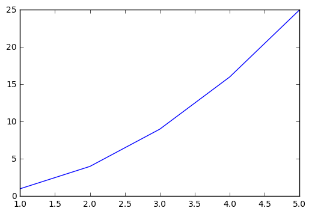

```python
# Creemos cinco puntos, cada uno con coordenada x e y:
coordenadas_en_las_x = np.array([1,2,3,4,5]) # Las coordenadas x de los cinco puntos
coordenadas_en_las_y = np.array([1,4,9,16,25]) # Las coordenadas y de los cinco puntos
# Y ahora dibujamos con plt.plot(eje_x, eje_y):
plt.plot(coordenadas_en_las_x, coordenadas_en_las_y)
```

El comando `plt.plot()` admite cientos de argumentos distintos. Por ejemplo, podemos querer que en vez de una línea, pinte los puntos sin unirlos, pasando un tercer argumento que sea el string `"o"` (que se parece a un puntito, ¿no?):

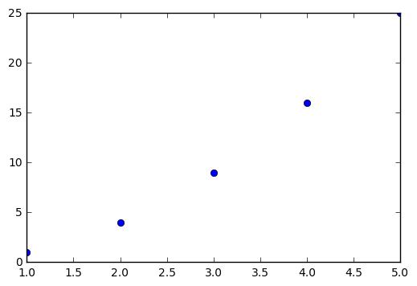

```python
plt.plot(coordenadas_en_las_x, coordenadas_en_las_y, "o")
```

¿Y si queremos nuestra línea verde?

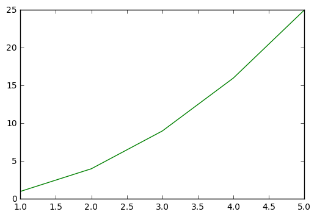

```python
plt.plot(coordenadas_en_las_x, coordenadas_en_las_y, "g") # "g" de green
```

¿Y si queremos puntos verdes? Pues combinamos los dos anteriores, en el mismo string:

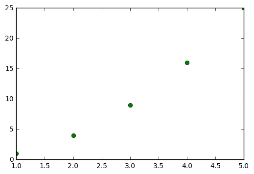

```python
plt.plot(coordenadas_en_las_x, coordenadas_en_las_y, "go")
```

Es común querer definir una sola vez las coordenadas de puntos en las x, pero para cada una querer varias coordenadas en la y:

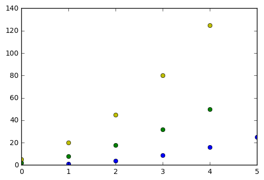

```python
# Generamos más coordenadas en las ys:
mas_coordenadas_en_las_y = coordenadas_en_las_y * 2
aun_mas_coordenadas_en_las_y = coordenadas_en_las_y * 5

plt.plot(coordenadas_en_las_x, coordenadas_en_las_y, "o",
         mas_coordenadas_en_las_y, "go",
         aun_mas_coordenadas_en_las_y, "yo") # "y" de yellow
```

Otras muchas veces queremos dibujar funciones conocidas. Supongamos que queremos dibujar:

$$f(x) = 3x + 2$$

Pues primero definimos la longitud de nuestro eje x, de nuevo, con puntos:

```python
puntos_eje_x = np.arange(0,51)
puntos_eje_x
```

```
array([ 0,  1,  2,  3,  4,  5,  6,  7,  8,  9, 10, 11, 12, 13, 14, 15, 16,
       17, 18, 19, 20, 21, 22, 23, 24, 25, 26, 27, 28, 29, 30, 31, 32, 33,
       34, 35, 36, 37, 38, 39, 40, 41, 42, 43, 44, 45, 46, 47, 48, 49, 50])
```

Aplicamos la función a cada uno de nuestro puntos:

```python
puntos_eje_y = 3 * puntos_eje_x + 2
puntos_eje_y
```

```
array([  2,   5,   8,  11,  14,  17,  20,  23,  26,  29,  32,  35,  38,
        41,  44,  47,  50,  53,  56,  59,  62,  65,  68,  71,  74,  77,
        80,  83,  86,  89,  92,  95,  98, 101, 104, 107, 110, 113, 116,
       119, 122, 125, 128, 131, 134, 137, 140, 143, 146, 149, 152])
```

Y ahora simplemente dibujamos:

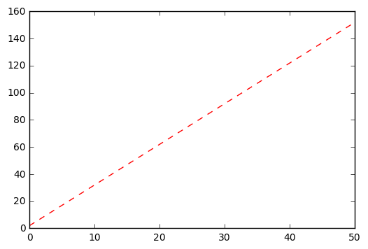

```python
plt.plot(puntos_eje_x, puntos_eje_y, "r--") # "r" de red y "--" de rayitas
```

### 10.A. Control de los gráficos

Los gráficos anteriores están hechos muy "a pelo". Sin controlar tamaño, título, ejes y similares. La forma correcta es, primero, decirle a Matplotlib que queremos generar una nueva figura con `plt.figure()`:

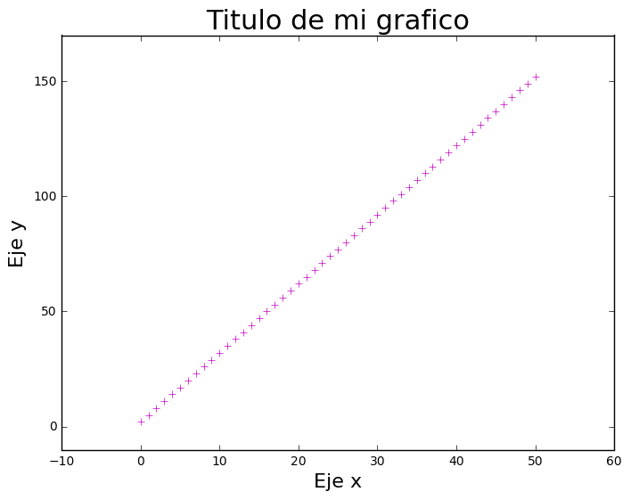

```python
plt.figure(figsize=(8,6)) # A plt.figure() le podemos pasar
                          # muchos argumentos, como el ancho
                          # y alto de la figura (en pulgadas).

# Todo lo que hagamos, definamos y dibujemos a partir de ahora
# formará parte de esa figura, hasta que decidamos volver
# a escribir plt.figure(); con esto, le diremos a Matplotlib
# que cambiamos de figura.

# Así que podemos ir configurando la figura sobre la que
# estamos trabajando:

plt.title("Titulo de mi grafico", fontsize=22) # Título arriba del gráfico
plt.xlabel("Eje x", fontsize=16) # Label del eje x
plt.ylabel("Eje y", fontsize=16) # Label del eje y
plt.axis([-10, 60, -10, 170]) # Mínimos y máximos de los ejes.
                              # Los dos primeros números son
                              # min y max del eje x. Los otros
                              # dos, del y.

# Y ya dibujamos:
plt.plot(puntos_eje_x, puntos_eje_y, "m+") # "m" de magenta, y + de puntitos mas.
```

Matplotlib destaca por el increíble nivel de personalización que se puede utilizar. TODO es configurable. Por desgracia, existe más de una forma por lo general de cambiar X característica o elemento del gráfico, lo cual suele desesperar a los usuarios noveles. La [documentación de Matplotlib](http://matplotlib.org/contents.html) es tan extensa que ofende, sinceramente.

Muchas veces no queremos pasarnos horas configurando paletas de colores y similares; solo queremos que los gráficos queden bien. Y Matplotlib tiene la fama de ser feo. Si bien por defecto es así, existe una forma muy sencilla de utilizar uno de los temas de color incorporados:

```
plt.style.use("nombre_de_tema_de_color")
```

```python
plt.style.use("ggplot") # Si eres usuario de R, probablemente lo reconozcas
```

Así se aplicará ese esquema de color en todas las figuras que hagamos, hasta que decidamos volver a cambiarlo más abajo en el código.

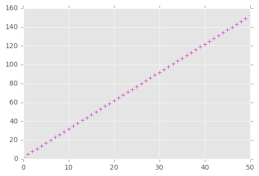

```python
plt.plot(puntos_eje_x, puntos_eje_y, "m+")
```

Igual no te gusta. Volvamos a cambiarlo:

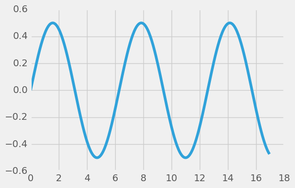

```python
plt.style.use("fivethirtyeight")

# Vamos a dibujar una función seno f(x) = 0.5 * sin(x):
puntos_eje_x = np.arange(0, 17, 0.05)
plt.plot(puntos_eje_x, 0.5 * np.sin(puntos_eje_x)) # np.sin() es otra de las ufuncs
```

```python
plt.style.use("ggplot") # Lo dejamos en ggplot; que el otro no me gusta.

# Todos los disponibles están aquí:
for theme in sorted(plt.style.available):
    print(theme)
```

```
bmh
classic
dark_background
fivethirtyeight
ggplot
grayscale
seaborn-bright
seaborn-colorblind
seaborn-dark
seaborn-dark-palette
seaborn-darkgrid
seaborn-deep
seaborn-muted
seaborn-notebook
seaborn-paper
seaborn-pastel
seaborn-poster
seaborn-talk
seaborn-ticks
seaborn-white
seaborn-whitegrid
```

Además, podemos dividir una figura en dos "subfiguras", llamadas `subplot`s en Matplotlib:

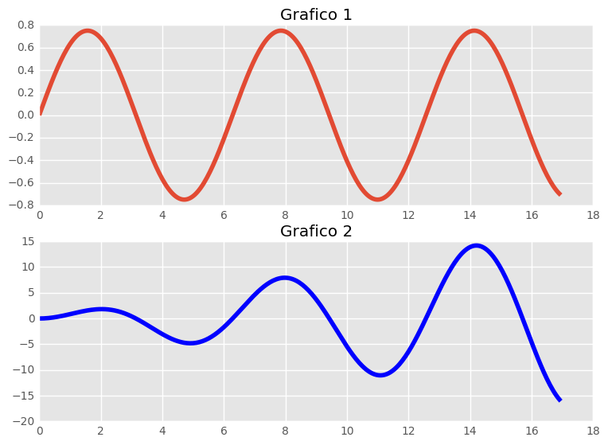

```python
# Creamos una nueva figure
plt.figure(figsize=(8,6))

# Y añadimos el primer gráfico con un subplot.
# Explico los números (2,1,1):
# El primero quiere decir cuántos gráficos va a haber a lo alto.
# El segundo, cuántos gráficos va a haber a lo ancho.
# El tercero, qué "número" va a tener el siguiente que vamos
# a dibujar. Como es el primero del conjunto, ponemos 1:
plt.subplot(2,1,1)
plt.title("Grafico 1")
plt.plot(puntos_eje_x, 0.75 * np.sin(puntos_eje_x))

# Los primeros dos números no cambian; pero es "el segundo"
# gráfico en aparecer, así que el tercer número es un 2:
plt.subplot(2,1,2)
plt.title("Grafico 2")
plt.plot(puntos_eje_x, np.sin(puntos_eje_x) * puntos_eje_x, "b")

# Por último, podemos guardar los gráficos (el último generado)
# a formato png con plt.savefig():
plt.savefig("C:\\Users\\julioantonio.sotodev\\Documents\\Curso Python\\grafico.png",
            dpi=300,
            orientation="landscape")
```

Vamos a dejar Matplotlib de momento. Volveremos a él cuando empecemos con pandas y los análisis estadísticos descriptivos, ya que Maptlotlib se integra perfectamente con los DataFrames, y nos permite sacar gráficos de una forma increíblemente sencilla.

De todos modos, [aquí](http://matplotlib.org/gallery.html) puedes ver la galería de Matplotlib, con ejemplos y el código de cada una de las visualizaciones de muestra.

Profesor: [Julio Antonio Soto](https://twitter.com/julio_a_soto)